# Untitled

Juan David Garcia Zapata

2023-11-18

```r
# Sangría con espacios
texto_con_sangria <- "    Este es un texto con sangría utilizando espacios."
cat(texto_con_sangria, "\n")
```

```
##     Este es un texto con sangría utilizando espacios.
```

```r
# Sangría con tabulación
texto_con_sangria_tab <- "\tEste es un texto con sangría utilizando tabulación."
cat(texto_con_sangria_tab, "\n")
```

```
##  Este es un texto con sangría utilizando tabulación.
```

# Introducción

Con el propósito de poner en práctica los conocimientos adquiridos en la materia, llevaremos a cabo un experimento centrado en helicópteros de papel. Este enfoque resulta fascinante debido a la diversidad de diseños disponibles que buscan mejorar la aerodinámica. En particular, nos concentraremos en el modelo propuesto por la NASA, el cual se encuentra detallado en el siguiente enlace: [Helicóptero de Papel de la NASA](https://ciencia.nasa.gov/sistema-solar/helicopterodepapel/). En esta unidad experimental, aplicaremos la metodología de Diseños de Experimentos (DoE), considerando variaciones en las alas y el tipo de material utilizado. Además, incorporaremos un bloque, teniendo en cuenta que el rendimiento de vuelo puede verse influenciado por el fabricante del avión.

# Diseño a emplear

Para el experimento utilizaremos un diseño factorial de dos factores+ Bloque, Donde:

Factores

**Material**: Con el que se hizo el helicoptero  
*Niveles*:  
*1)* Hoja de impresora(resma).  
*2)* Hoja de cuaderno.

**Longitud**: Las dimenciones de cada ala del helicoptero

*Niveles*:

*1)* 5cm

*2)* 3cm

**Bloque**: Fabricantes

En este caso tendremos n frabricantes por numero de replicas. **Variable respuesta**: Tiempo

# Modelo a utilizar

$$y_{ijk} = \mu + \tau_{i} + (\tau \beta)_{ij} + \delta_{k} + \varepsilon
_{ijk}
\begin{cases}
i=1,2,....,a \\
j=1,2,....,b \\
k=1,2,....,n
\end{cases}$$
# Determinacion de replicas

Para determinar cuantas replicas hay que hacer hacemos una prueba piloto con una sola combinación por lo cual la piloto se hizo con la combinaión material (hoja de resma) y Longitud (5cm), de esta se realizo 10 replicas

```r
library(daewr)
rmin <-2
rmax <-6
x = c(3.78, 3.56, 3.57, 3.43, 3.5, 3.09, 4.08, 3.32, 3.24, 3.38)
alpha <- rep(0.05, rmax - rmin +1)
sigma <-sd(x)
nlev <- 4
nreps <- rmin:rmax

Delta <- 1
power <- Fpower1(alpha,nlev,nreps,Delta,sigma)
power
```

```
##      alpha nlev nreps Delta     sigma     power
## [1,]  0.05    4     2     1 0.2809607 0.4411098
## [2,]  0.05    4     3     1 0.2809607 0.8232324
## [3,]  0.05    4     4     1 0.2809607 0.9592504
## [4,]  0.05    4     5     1 0.2809607 0.9922678
## [5,]  0.05    4     6     1 0.2809607 0.9987205
```

De acuerdo a lo anterior de a lo anterior nesecitamos 3 replicas para alcanzar una potencia el 82% por lo cual significa que necesitamos 3 fabricantes

# Ejecución del experimento

# Aleatorización

Para definir cual es el orden en que el fabricante debe hacer los helicopteros ns ayudamos del siguiente codigo

```r
#Material1: Impresora
#material2: Cuaderno
set.seed(50)
medidas_alas = c(5,3)
materiales = c("Mat1", "Mat2")
Block = c("Mateo","crhistofer", "Juan")

DESIGN = replicate(3, sample(c("Mat 1:Lon 5","Mat 1:Lon 3","Mat 2:Lon 5","Mat 2:Lon 3"),4))
colnames(DESIGN) = Block
DESIGN
```

```
##      Mateo         crhistofer    Juan
## [1,] "Mat 2:Lon 3" "Mat 2:Lon 5" "Mat 2:Lon 5"
## [2,] "Mat 2:Lon 5" "Mat 1:Lon 3" "Mat 1:Lon 3"
## [3,] "Mat 1:Lon 3" "Mat 2:Lon 3" "Mat 1:Lon 5"
## [4,] "Mat 1:Lon 5" "Mat 1:Lon 5" "Mat 2:Lon 3"
```

# Realizacion del Experimeto

Después de llevar a cabo los helicopteros , procuramos maximizar el control sobre los factores controlables, tales como el viento, el lanzador y la altura. En este contexto, realizamos la prueba en un entorno cerrado con el fin de gestionar con precisión la influencia del viento. Posteriormente, optamos por utilizar un único lanzador para minimizar la variabilidad, y establecimos una altura constante para todas las pruebas y asi tomar el tiempo de vuelo en este caso sospechabamos que la persona que tomara el tiempo habria variablidad de cuando realmente paraba el cronometro y cuando el heliptero tocaba el suelo, ya que el tiempo se tomaba desde que el lanzador lo suelta hasta que toque el suelo, por esto decidimos que 2 personas tomaran el tiempo y promediar el tiempo de los 2

# aleatorización

Con el objetivo de prevenir la aparición de patrones en los lanzamientos, procedimos a aleatorizar la disposición de los helicópteros antes de cada lanzamiento.

```r
set.seed(1)
# Original sequence
original_sequence <- c("Mat 1:Lon 5", "Mat 1:Lon 3", "Mat 2:Lon 5", "Mat 2:Lon 3",
                       "Mat 1:Lon 5", "Mat 1:Lon 3", "Mat 2:Lon 5", "Mat 2:Lon 3",
                       "Mat 1:Lon 5", "Mat 1:Lon 3", "Mat 2:Lon 5", "Mat 2:Lon 3")

# Randomize the sequence
randomized_sequence <- sample(original_sequence)

# Display the randomized sequence
print(randomized_sequence)
```

```
##  [1] "Mat 1:Lon 5" "Mat 2:Lon 3" "Mat 2:Lon 5" "Mat 1:Lon 5" "Mat 1:Lon 3"
##  [6] "Mat 1:Lon 5" "Mat 2:Lon 5" "Mat 2:Lon 3" "Mat 1:Lon 3" "Mat 2:Lon 5"
## [11] "Mat 2:Lon 3" "Mat 1:Lon 3"
```

Tomados los datos los organizamos en r

```r
# VA EN FILAS

y <-c(3.1   ,3.34   ,3.6,   3.17,   3.21,   3.51,
      3.88, 3.27,   3.77,   3.92,   3.85,   3.53)
Longitud <- factor(rep(c(5,3), each=6))


Material <- factor(rep(c("Impresora","Cuaderno","Impresora","Cuaderno","Impresora","Cuaderno"), 2))


Fabricante <- factor(rep(c("Mateo","Mateo","Juan","Juan","Cristofer","Cristofer"),  2))
t <- data.frame(y,Longitud,Material,Fabricante)
```

# Modelos

Primero que todo hacemos un modelo con todas las variable, bloque y interacción, para mirar que variables son significativas

```r
modelo1 = aov(y ~  Longitud*Material+Fabricante)
anova(modelo1)
```

```
## Analysis of Variance Table
##
## Response: y
##                   Df  Sum Sq Mean Sq F value  Pr(>F)
## Longitud           1 0.43701 0.43701  8.1722 0.02885 *
## Material           1 0.03741 0.03741  0.6995 0.43497
## Fabricante         2 0.09555 0.04777  0.8934 0.45748
## Longitud:Material  1 0.06601 0.06601  1.2344 0.30909
## Residuals          6 0.32085 0.05347
## ---
## Signif. codes:  0 '***' 0.001 '**' 0.01 '*' 0.05 '.' 0.1 ' ' 1
```

Con este modelo, ni el material utilizado ni el fabricante (es decir, quien confecciona los helicópteros) parecen tener un impacto significativo en el tiempo de vuelo. En cambio, hemos observado que la duración del vuelo se ve afectada únicamente por las dimensiones de las alas.

```r
modelo2 <- aov(y~Longitud)
anova(modelo2)
```

```
## Analysis of Variance Table
##
## Response: y
##           Df  Sum Sq Mean Sq F value  Pr(>F)
## Longitud   1 0.43701 0.43701   8.407 0.01585 *
## Residuals 10 0.51982 0.05198
## ---
## Signif. codes:  0 '***' 0.001 '**' 0.01 '*' 0.05 '.' 0.1 ' ' 1
```

Este modelo reducido, Longuitud sigue siendo significativo es decir el bloue no esta emascarillando el factor

# Analisis de supuestos

## Normalidad

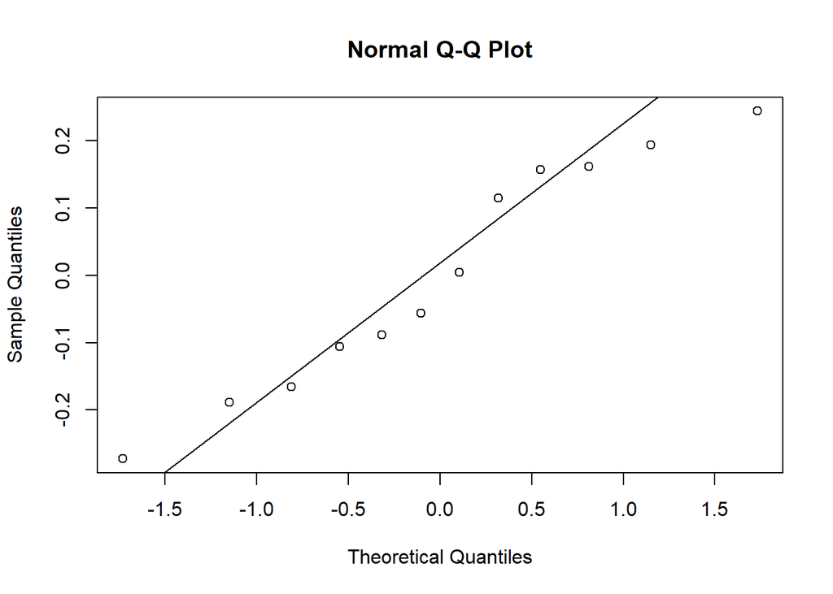

```r
qqnorm(modelo1$residuals)
qqline(modelo1$residuals)
```

Graficamente prodemos ver que aunque hay un punto un poco alejado podemos notar que hay normalidad pero para esto haremos una prueba teorica

```r
shapiro.test(modelo1$residuals)
```

```
##
##  Shapiro-Wilk normality test
##
## data:  modelo1$residuals
## W = 0.94044, p-value = 0.5038
```

Con esta prueba efectivamente aceptamos normalidad

## Varianza costante

Para esto probaremos Si longutud y Material cumplen con este supesto por lo cual haremos de una ves la prueba del test de bartlett

### Material

```r
bartlett.test(y, Material)
```

```
##
##  Bartlett test of homogeneity of variances
##
## data:  y and Material
## Bartlett's K-squared = 0.24918, df = 1, p-value = 0.6177
```

### Longitud

```r
bartlett.test(y, Longitud)
```

```
##
##  Bartlett test of homogeneity of variances
##
## data:  y and Longitud
## Bartlett's K-squared = 0.26653, df = 1, p-value = 0.6057
```

En este caso los dos factores si cumplen con el supuesto de varianza constanet

```r
#interaction.plot(Longitud, Material, y)
```

```r
TukeyHSD(modelo2)
```

```
##   Tukey multiple comparisons of means
##     95% family-wise confidence level
##
## Fit: aov(formula = y ~ Longitud)
##
## $Longitud
##           diff        lwr         upr     p adj
## 5-3 -0.3816667 -0.6749631 -0.08837027 0.0158478
```

En la prueba de Tukey, al notar que el intervalo de confianza no incluye el valor cero, se infiere que las medias son estadísticamente diferentes. En síntesis, los helicópteros de papel con alas de 3 cm exhiben un tiempo de vuelo significativamente superior en comparación con aquellos que poseen alas de 5 cm ya que l diff es negativo por lo que significa que la media de 3 es mayor a las de 5. En consecuencia, en términos de duración de vuelo, se puede considerar que las alas de 3 cm son más efectivas.